# Genomic sequencing

October 7, 2021

The steps taken in this analysis are ordered as followed with optional sections marked to be used based on the availability of data and desired resolution and output.

1. Upload data and identify missing data
2. Whole versus partial genome sequencing
3. Initial visualization using RABV GLUE rough clade assignment
4. Partition sequences based on genome region
5. Run sequences through MADDOG and format output
6. Graphical and spatial visualization of lineages at a country level
7. Preparation of data for regional level analysis
8. Graphical and spatial visualization of lineages at a regional level

# 1-Upload data and identify missing data points

## Setting up data and loading libraries

```r
rm(list=ls())
metadata<-read.csv("/Users/emiliawilkins/Downloads/00- GitHub/SEA-RABV_genSurv/A- rabies project/RABV downloads/METADATA/00- Final datasets/SEA_RABV_all_r.csv")
attach(metadata)
library(dplyr) #For filtering and sorting data
library(ggplot2)
```

Separate out sequences with missing datapoints. Run code for any variables needed to fill in further.

## Sorting out missing information

```r
#Missing country
country_miss<-filter(metadata,sequence.m49_country.display_name == '-')
#Missing date
date_miss<-filter(metadata, sequence.collection_year == '-')
#Missing host
host_miss<-filter(metadata,sequence.host == '-')
```

Identify sequences missing data and use NCBI GenBank (https://www.ncbi.nlm.nih.gov/genbank/) to find sample and locate information or search in associated journal articles. Once data has been filled in using the original metadata file, save and re-upload to code.

## Reupload metadata

```r
metadata<-read.csv("/Users/emiliawilkins/Downloads/00- GitHub/SEA-RABV_genSurv/A- rabies project/RABV downloads/METADATA/00- Final datasets/SEA_RABV_all_r.csv")
```

# 2-Whole versus partial genome sequencing

Create a new column and identify each sequence as a whole or partial genome. ## Add variable sorting sequences WGS versus partial sequences

```r
groupdata<-metadata %>%
  mutate(genomeregion = case_when(
    sequence.gb_length > 10000 ~ "WGS",
    sequence.gb_length < 10000 ~ "PGS"
  ))
```

## Graphs of sequence type over time/per country

**Need to fix collection year with sequencing year and add lubridate**

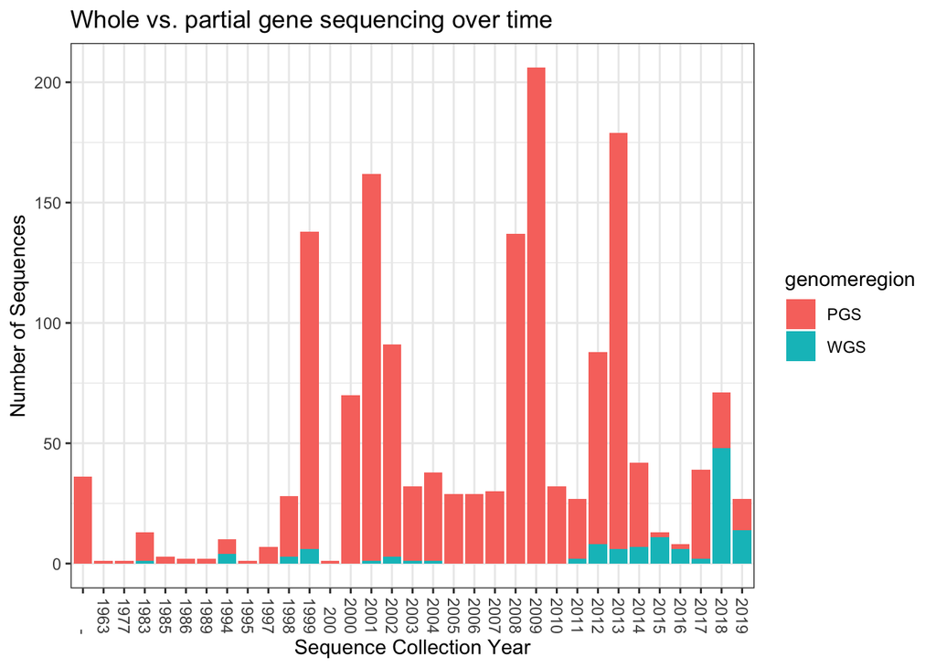

```r
#Bar graph of WGS:PGS over time

ggplot(groupdata, aes(x=sequence.collection_year)) + labs(x= "Sequence Collection Year", y= "Number of Sequences", colour= "Genome Region", title = "Whole vs. partial gene sequencing over time")+ geom_bar(aes(fill=genomeregion)) + theme_bw() + theme(axis.text.x = element_text(angle = 270, vjust = 0.5, hjust=1) )
```

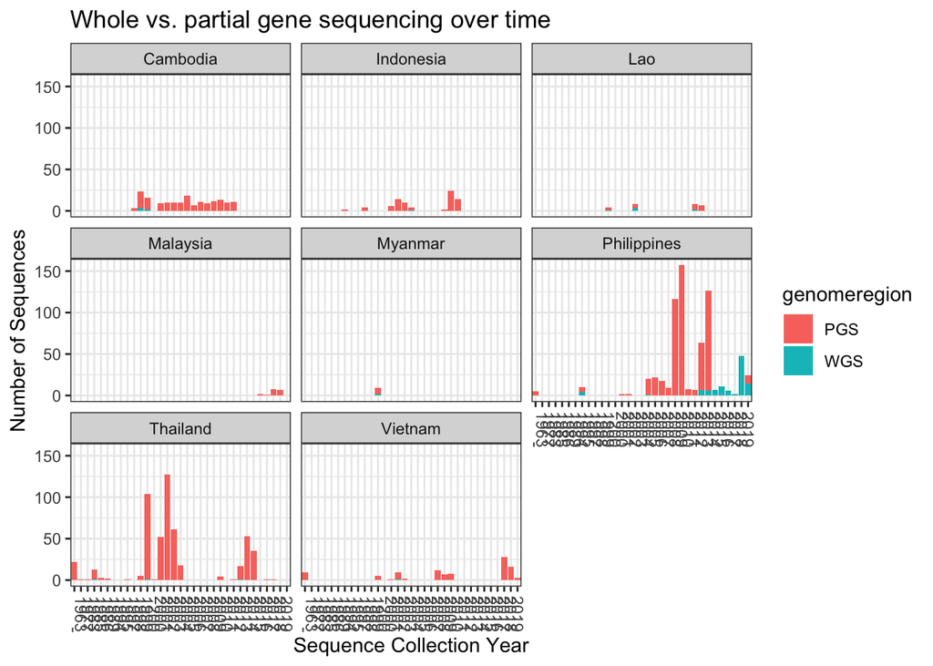

```r
#Faceted bar graph of WGS and Partial genome sequences over time per country
ggplot(groupdata, aes(x=sequence.collection_year)) + labs(x= "Sequence Collection Year", y= "Number of Sequences", colour= "Genome Region", title = "Whole vs. partial gene sequencing over time")+ geom_bar(aes(fill=genomeregion)) + theme_bw() + theme(axis.text.x = element_text(angle = 270, vjust = 0.5, hjust=1) ) + facet_wrap(~groupdata$sequence.m49_country.display_name)
```

# 3-Initial visualization using RABV GLUE rough clade assignment

## Loading libraries

```r
library(rnaturalearth)
library(rnaturalearthdata)
library(scatterpie)
library(gt)
library(rgeos)
```

## Sort mismatched data

Identify country names that may be different from those stored in Rnaturalearthdata package. Output lists country names that are incorrect. For example, “Tanzania” may need to be corrected to “United Republic of Tanzania”.

```r
#Contains clades from RABV GLUE
#Clean data
world<-ne_countries()
#extract information about the map

#Find which country names do not match between data and map file
map_countries<- as.character(world$admin)
countries<-unique(metadata$sequence.m49_country.display_name)
no_match<- setdiff(countries, map_countries); message(length(no_match), "countries are mis-matched: \n", paste0(no_match, collapse = "\n"))
```

```
## 1countries are mis-matched:
## Lao
```

Correct country names. Shown: “Lao” corrected to “Laos”

```r
metadata$sequence.m49_country.display_name[grepl("Lao", metadata$sequence.m49_country.display_name)] <- "Laos"
```

## Country/Clade summary outputs

```r
#List all countries included in metadata
countries<- unique(metadata$sequence.m49_country.display_name)


#Look at # sequences per country
country_table<-table(metadata$sequence.m49_country.display_name); country_table
```

```
##
##    Cambodia   Indonesia        Laos    Malaysia     Myanmar Philippines
##         172          80          27          18           9         664
##    Thailand     Vietnam
##         523         100
```

```r
length(country_table)
```

```
## [1] 8
```

## Process data

Sort data into table of subclade versus country

```r
#Make table w/ column for each subclade (+1 for countries) and a row for each country
lineage_table <- data.frame(matrix(ncol = (length(unique(metadata$alignment.displayName))+1), nrow = length(unique(metadata$sequence.m49_country.display_name))))

# Extract all the different subclades in the metadata, and assign these as column names
x <- c("country", unique(metadata$alignment.displayName))
colnames(lineage_table) <-x

# Add all the countries from the previous step to the "country" column
lineage_table$country<-countries

for (i in 1:length(countries)) {
  country_place<-which(lineage_table$country == countries[i])
  # For each country, on order, find which row of the lineage_table corresponds to it
  lineages<-unique(metadata$alignment.displayName[which(metadata$sequence.m49_country.display_name == countries[i])])
  # For this country, search the metadata and see which subclades have been seen in this country
  # Store this information

 for (j in 1:length(lineages)) {
    country_lineage<-which(colnames(lineage_table) == lineages[j])
    # For each subclade identified in the previous step in order, see which column corresponds to it
    lineage_table[country_place, country_lineage]<-
      length(which((metadata$alignment.displayName[which(metadata$sequence.m49_country.display_name == countries[i])]) == lineages[j]))
    # Count how many sequences in the metadata there are for both the country AND subclade of interest
    # This value is put into the corresponding box in the table
  }
}

# There are many boxes in the table that are NA - a particular subclade isn't seen in that country
# Turn these into 0's
lineage_table[is.na(lineage_table)] <- 0
```

Extract geographical info

```r
# Add columns to the table ready to be filled in with the Lat and Long values for each country
lineage_table$LAT<-NA
lineage_table$LON<-NA

# If needed, remove hashtag and procede: Remove problem values from the table as there will be no Lat and Long values for these
# Unclear why Grenada is a problem, but this was identified in the cleaning step
#lineage_table<-lineage_table[-c(which(lineage_table$country == "-")),]
#lineage_table<-lineage_table[-c(which(lineage_table$country == "Grenada")),]

# For each country in the lineage table, search for it in the 'world' map object we created earlier
# Find the corresponding polygon (spatial info is stored!) for the country
# The labpt option in the polygon contains the lat and long values in a single vector
# Therefore, these need to be indexed ([1] and [2])
# The values are then put in the corresponding LAT and LON columns
for (i in 1:length(lineage_table$country)) {
  lineage_table$LAT[i]<-world@polygons[which(world$admin == lineage_table$country[i])][[1]]@labpt[2]
  lineage_table$LON[i]<-world@polygons[which(world$admin == lineage_table$country[i])][[1]]@labpt[1]
}
```

Process data to be read into maps.

```r
#Count number of rows (countries) in the table
n<- nrow(lineage_table)
#Add a column that gives a number to each country
lineage_table$region <- factor(1:n)
# Add a column called "radius" which will be filled with information about the number of sequences
# This is so the size of the pies corresponds to the number of sequences
lineage_table$radius<-NA
# For each country, count the total number of sequences across all subclades
# Enter this information into the radius column
# The sum index looks a little odd; this is because we don't want to include the LAT, LON, region and radius values
# Therefore, we want to only use the columns that are for lineages
for (i in 1:length(lineage_table$country)) {
  lineage_table$radius[i]<-sum(lineage_table[i,2:(1+length(unique(metadata$alignment.displayName)))])
}

# Some of these radii are BIG; these would result in pies bigger than the map!
# Therefore, edit this so those with more sequences are larger, but reasonably sized
lineage_table$radius[which(lineage_table$radius %in% 6:10)]<-6
lineage_table$radius[which(lineage_table$radius %in% 11:20)]<-7
lineage_table$radius[which(lineage_table$radius %in% 21:50)]<-8
lineage_table$radius[which(lineage_table$radius %in% 51:100)]<-9
lineage_table$radius[which(lineage_table$radius %in% 101:200)]<-10
lineage_table$radius[which(lineage_table$radius > 200)]<-11

# Now we've settled on values, divide them all to make them small enough to look nice
lineage_table$radius<-lineage_table$radius/2
```

```r
print(lineage_table)
```

```
##       country Asian SEA3 Asian SEA1b Asian SEA4 Cosmopolitan Vac Cosmopolitan
## 1    Thailand        509          12          1                0            0
## 2   Indonesia          0          80          0                0            0
## 3     Vietnam         41          53          0                5            1
## 4 Philippines          0           0        664                0            0
## 5        Laos         27           0          0                0            0
## 6    Cambodia        172           0          0                0            0
## 7     Myanmar          9           0          0                0            0
## 8    Malaysia          7          11          0                0            0
##   Cosmopolitan AM4        LAT       LON region radius
## 1                1 15.0169750 101.00613      1    5.5
## 2                0 -0.2543016 114.02268      2    4.5
## 3                0 16.6579378 106.28584      3    4.5
## 4                0 15.7509443 121.54444      4    5.5
## 5                0 18.4449781 103.75026      5    4.0
## 6                0 12.6847286 104.87609      6    5.0
## 7                0 21.0169999  96.50584      7    3.0
## 8                0  3.5481118 114.67551      8    3.5
```

## Plot maps

Create world map to be plotted on with data

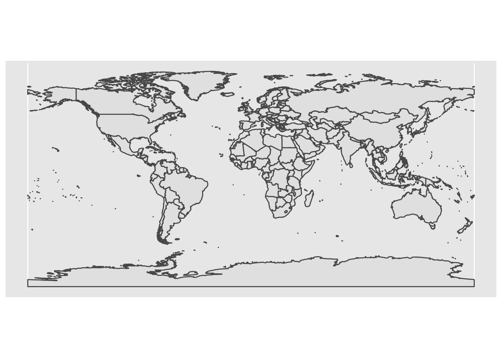

```r
#world data needs to be in slightly different form to plot it
world<- ne_countries(scale = "medium", returnclass = "sf")
# Plot a basic map which we will add pies to
plot<-
  ggplot(data = world) +
  geom_sf()
plot
```

Plot datapoints from lineage_table onto world map using geom_scatterpie. Spatial mapping uses longitude, latitude, and region and radius (defined in the lineage table).

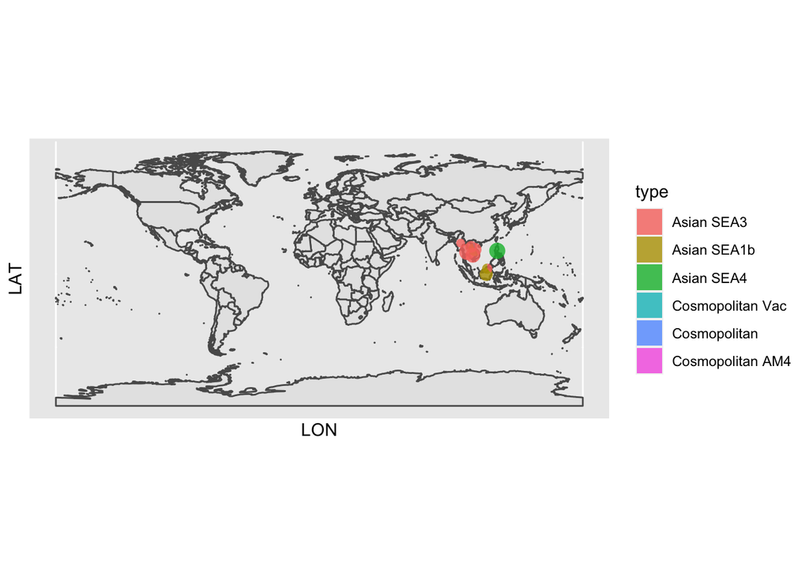

```r
# We also tell it what the names of the different elements in the pies are (the subclades)
plot_world<-plot + geom_scatterpie(aes(x=LON, y=LAT, group=region, r=radius),
                                   data=lineage_table, cols=c(colnames(lineage_table)[2:(1+length(unique(metadata$alignment.displayName)))]), color=NA, alpha=.8)

plot_world
```

If the analysis is conducted using data from a smaller regional area than is shown with the world map, this step can zoom the map in on using the xlim and ylim functions in the last line of this code block. Choose values based on the boundaries of the data shown in the world map.

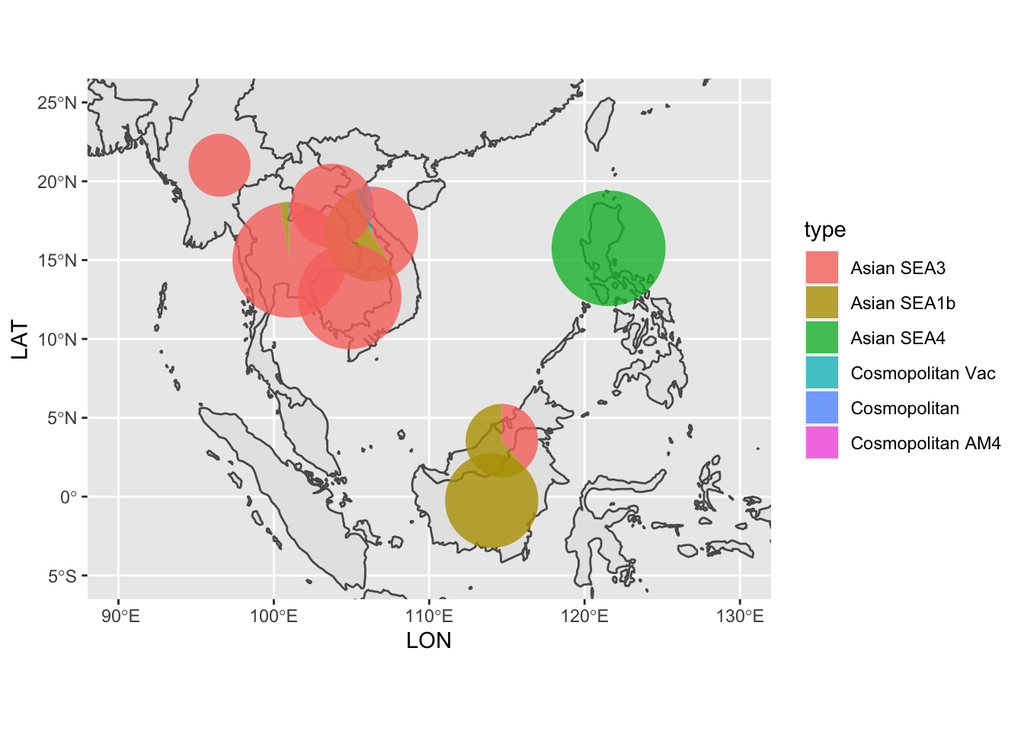

```r
# Some of the areas are difficult to see clearly on the world map, so we can zoom in with an extra argument
# We can also adjust the radii to be smaller so it's easier to distinguish countries when we zoom in
lineage_table$radius<-lineage_table$radius/1.5

plot_zoom<-plot + geom_scatterpie(aes(x=LON, y=LAT, group=region, r=radius),
                                  data=lineage_table, cols=c(colnames(lineage_table)[2:(1+length(unique(metadata$alignment.displayName)))]), color=NA, alpha=.8,)+
  coord_sf(xlim = c(90,130), ylim = c(-5,25))

plot_zoom
```

# 4- Partition sequences based on genome region

In order to run sequences through MADDOG (https://github.com/KathrynCampbell/MADDOG), datasets need to be partitioned into genome region.

# 5- MADDOG

Upload sequence data and associated metadata to MADDOG command line for each genome region selected for analysis. Combine lineage given in sequence information output file with metadata file and upload to R. (https://github.com/KathrynCampbell/MADDOG)

For the rest of the code, WGS data will be used to demonstrate the process. During the MADDOG process, metadata must be re-labelled as “date”, “country”, and “ID”.

# 6- PIE MAPS LINEAGE COUNTRY

```r
countrydata<-read.csv("/Users/emiliawilkins/Downloads/00- GitHub/wgs_all/wgs_all_metadata.csv")
countrydata<-na.omit(countrydata)
```

```r
#brought from above, separate graphs for WGS and Partial
#Contains clades from RBV GLUE
#Clean data
world<-ne_countries()
#extract information about the map

#Find which country names do not match between data and map file
map_countries<- as.character(world$admin)
countries<-unique(countrydata$country)
no_match<- setdiff(countries, map_countries); message(length(no_match), "countries are mis-matched: \n", paste0(no_match, collapse = "\n"))
```

```
## 1countries are mis-matched:
## Lao
```

```r
countrydata$country[grepl("Lao", countrydata$country)] <- "Laos"
```

Some summaries

```r
#List all countries included in metadata
countries<- unique(countrydata$country)


#Look at # sequences per country
country_table<-table(countrydata$country); country_table
```

```
##
##    Cambodia   Indonesia        Laos     Myanmar Philippines    Thailand
##           5           1           6           2         105           3
##     Vietnam
##           1
```

```r
length(country_table)
```

```
## [1] 7
```

Process data

```r
#Make table w/ column for each subclade (+1 for countries) and a row for each country
lineage_table <- data.frame(matrix(ncol = (length(unique(countrydata$lineage))+1), nrow = length(unique(countrydata$country))))

# Extract all the different subclades in the metadata, and assign these as column names
x <- c("country", unique(countrydata$lineage))
colnames(lineage_table) <-x

# Add all the countries from the previous step to the "country" column
lineage_table$country<-countries

for (i in 1:length(countries)) {
  country_place<-which(lineage_table$country == countries[i])
  # For each country, on order, find which row of the lineage_table corresponds to it
  lineages<-unique(countrydata$lineage[which(countrydata$country == countries[i])])
  # For this country, search the metadata and see which subclades have been seen in this country
  # Store this information

 for (j in 1:length(lineages)) {
    country_lineage<-which(colnames(lineage_table) == lineages[j])
    # For each subclade identified in the previous step in order, see which column corresponds to it
    lineage_table[country_place, country_lineage]<-
      length(which((countrydata$lineage[which(countrydata$country == countries[i])]) == lineages[j]))
    # Count how many sequences in the metadata there are for both the country AND subclade of interest
    # This value is put into the corresponding box in the table
  }
}

# There are many boxes in the table that are NA - a particular subclade isn't seen in that country
# Turn these into 0's
lineage_table[is.na(lineage_table)] <- 0
```

Extract geographical info Come back in with admin level data, for now stick to country

```r
# Add columns to the table ready to be filled in with the Lat and Long values for each country
lineage_table$LAT<-NA
lineage_table$LON<-NA

# Remove problem values from the table as there will be no Lat and Long values for these
# Unclear why Grenada is a problem, but this was identified in the cleaning step
#lineage_table<-lineage_table[-c(which(lineage_table$country == "-")),]
#lineage_table<-lineage_table[-c(which(lineage_table$country == "Grenada")),]

# For each country in the lineage table, search for it in the 'world' map object we created earlier
# Find the corresponding polygon (spatial info is stored!) for the country
# The labpt option in the polygon contains the lat and long values in a single vector
# Therefore, these need to be indexed ([1] and [2])
# The values are then put in the corresponding LAT and LON columns
for (i in 1:length(lineage_table$country)) {
  lineage_table$LAT[i]<-world@polygons[which(world$admin == lineage_table$country[i])][[1]]@labpt[2]
  lineage_table$LON[i]<-world@polygons[which(world$admin == lineage_table$country[i])][[1]]@labpt[1]
}
```

Continued

```r
#Data needs to be processed in a way that can be read into maps
#Count number of rows (countries) in the table
n<- nrow(lineage_table)
#Add a column that gives a number to each country
lineage_table$region <- factor(1:n)
# Add a column called "radius" which will be filled with information about the number of sequences
# This is so the size of the pies corresponds to the number of sequences
lineage_table$radius<-NA
# For each country, count the total number of sequences across all subclades
# Enter this information into the radius column
# The sum index looks a little odd; this is because we don't want to include the LAT, LON, region and radius values
# Therefore, we want to only use the columns that are for lineages
for (i in 1:length(lineage_table$country)) {
  lineage_table$radius[i]<-sum(lineage_table[i,2:(1+length(unique(countrydata$lineage)))])
}

# Some of these radii are BIG; these would result in pies bigger than the map!
# Therefore, edit this so those with more sequences are larger, but reasonably sized
lineage_table$radius[which(lineage_table$radius %in% 6:10)]<-6
lineage_table$radius[which(lineage_table$radius %in% 11:20)]<-7
lineage_table$radius[which(lineage_table$radius %in% 21:50)]<-8
lineage_table$radius[which(lineage_table$radius %in% 51:100)]<-9
lineage_table$radius[which(lineage_table$radius %in% 101:200)]<-10
lineage_table$radius[which(lineage_table$radius > 200)]<-11

# Now we've settled on values, divide them all to make them small enough to look nice
lineage_table$radius<-lineage_table$radius/2
print(lineage_table)
```

```
##       country Asian SEA4_E1 Asian SEA4_C1.1 Asian SEA4_A1.2.2 Asian SEA4_A1.2.1
## 1 Philippines            16              10                 5                 8
## 2        Laos             0               0                 0                 0
## 3    Thailand             0               0                 0                 0
## 4     Myanmar             0               0                 0                 0
## 5    Cambodia             0               0                 0                 0
## 6     Vietnam             0               0                 0                 0
## 7   Indonesia             0               0                 0                 0
##   Asian SEA4_A1.2 Asian SEA4_C1 Asian SEA3_B1.1 Asian SEA3_B1 Asian SEA4_A1.1
## 1               3             7               0             0               4
## 2               0             0               6             0               0
## 3               0             0               2             1               0
## 4               0             0               0             2               0
## 5               0             0               5             0               0
## 6               0             0               1             0               0
```

[output cut: 17 more lines]

Make the maps

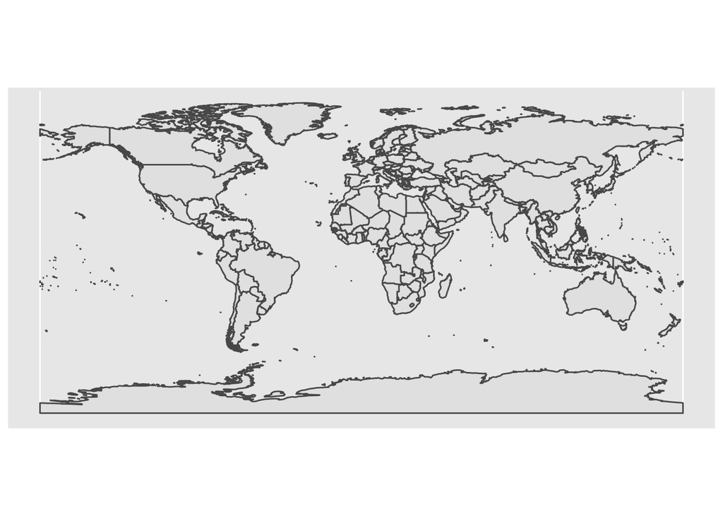

```r
library(rgeos)
#world data needs to be in slightly different form to plot it
world<- ne_countries(scale = "medium", returnclass = "sf")
# Plot a basic map which we will add pies to
plot<-
  ggplot(data = world) +
  geom_sf()
plot
```

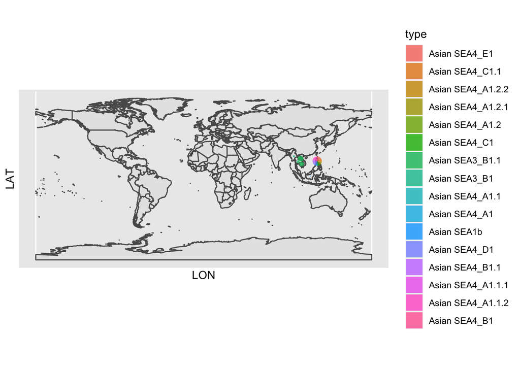

```r
# We are taking the basic map from the last step and telling geom_scatterpie there is data in the lineage_table
# It then uses the LON, LAT, region and radius columns we made in the last step
# We also tell it what the names of the different elements in the pies are (the subclades)
plot_world<-plot + geom_scatterpie(aes(x=LON, y=LAT, group=region, r=radius),
                                   data=lineage_table, cols=c(colnames(lineage_table)[2:(1+length(unique(countrydata$lineage)))]), color=NA, alpha=.8)

plot_world
```

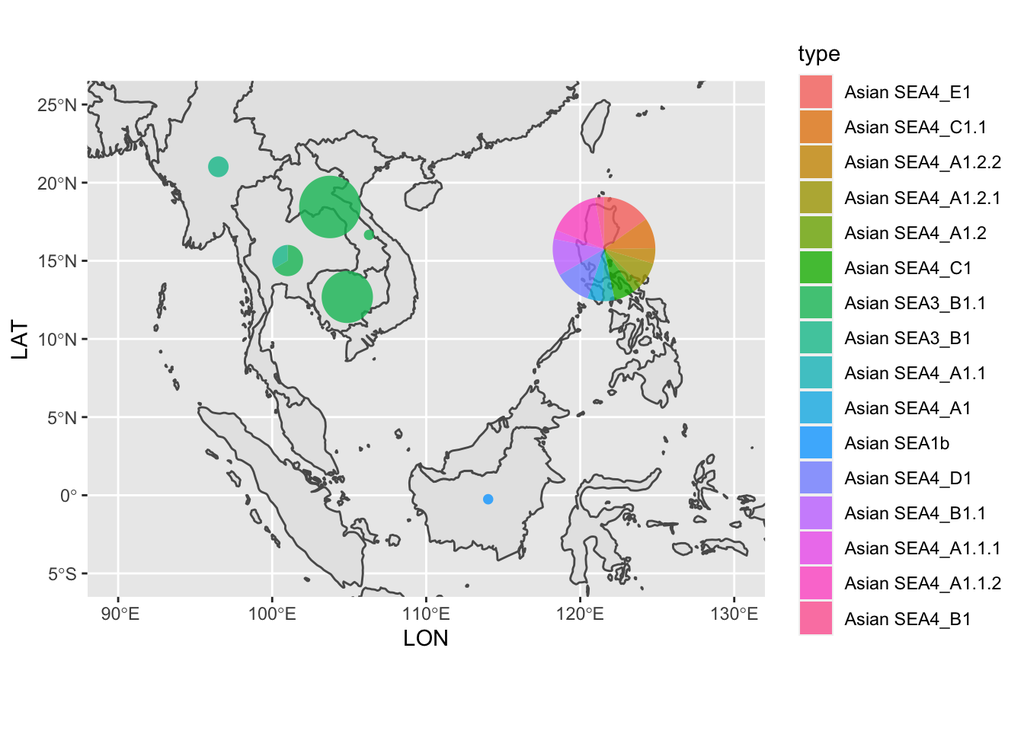

```r
# Some of the areas are difficult to see clearly on the world map, so we can zoom in with an extra argument
# We can also adjust the radii to be smaller so it's easier to distinguish countries when we zoom in
lineage_table$radius<-lineage_table$radius/1.5

plot_zoom<-plot + geom_scatterpie(aes(x=LON, y=LAT, group=region, r=radius),
                                  data=lineage_table, cols=c(colnames(lineage_table)[2:(1+length(unique(countrydata$lineage)))]), color=NA, alpha=.8,)+
  coord_sf(xlim = c(90,130), ylim = c(-5,25))

plot_zoom
```

# 7-SEPARATING PHILIPPINES DATASETS

Partitioning code does not apply to this analysis since WGS data was used, but standard filtering code will apply.

# 8-PIE CHARTS LINEAGE REGIONAL

Shapefiles obtained from https://data.humdata.org and metadata curated was standardized to the csv file provided with this data.

```r
library(dplyr)
library(writexl)
library(rnaturalearth)
library(rnaturalearthdata)
library(scatterpie)
library(rgdal)
```

```r
metadata<-read.csv("/Users/emiliawilkins/Downloads/00- GitHub/Phil metadata subsets/wgs_phl_metadata.csv")

shape_region<-readOGR("/Users/emiliawilkins/Downloads/00- GitHub/SEA-RABV_genSurv/PHL administrative boundaries/PHL_adm3.shp")
```

Remove sequences with no location data

```r
metadata<-na.omit(metadata)
```

Cleaning Data

Extract information about places in the shapefiles (Name_1 corresponds to the province)

```r
map_regions<-as.character(shape_region@data$NAME_1)

#Find which place names do not match between data and shapefiles
areas<- unique(metadata$location)
no_match<- setdiff(areas, map_regions); message(length(no_match), "places are mis-matched")
```

```
## 0places are mis-matched
```

```r
no_match
```

```
## character(0)
```

Check out number of sequences per province

```r
# List all the areas included in the metadata
areas <- unique(metadata$location)

# Have a quick look at the number of sequences per place, and the total number of places
areas_table<-table(metadata$location); areas_table
```

```
##
##               Albay              Bataan            Batangas             Bulacan
##                   6                   1                   3                   1
##       Camarines Sur              Cavite   Compostela Valley     Davao del Norte
##                   1                   8                   2                  26
##       Davao del Sur              Laguna         Maguindanao Metropolitan Manila
##                  20                   7                   1                  13
##         Nueva Ecija    Oriental Mindoro            Pampanga          Pangasinan
##                   1                   1                   2                   1
##              Quezon               Rizal
##                   3                   3
```

```r
length(areas_table)
```

```
## [1] 18
```

Processing data: Table with each subclade and row for each location

```r
# Make a table with a column for each subclade (+1 for areas) and a row for each area
lineage_table <- data.frame(matrix(ncol = (length(unique(metadata$lineage))+1), nrow = length(areas)))

# Extract all the different subclades in the metadata, and assign these as column names
x <- c("area", unique(metadata$lineage))
colnames(lineage_table) <- x

# Add all the areas from the previous step to the "area" column
lineage_table$area<-areas

for (i in 1:length(areas)) {
  country_place<-which(lineage_table$area == areas[i])
  # For each area, on order, find which row of the lineage_table corresponds to it
  lineages<-unique(metadata$lineage[which(metadata$location == areas[i])])
  # For this area, search the metadata and see which subclades have been seen in this area
  # Store this information

  for (j in 1:length(lineages)) {
    country_lineage<-which(colnames(lineage_table) == lineages[j])
    # For each subclade identified in the previous step in order, see which column corresponds to it
    lineage_table[country_place, country_lineage]<-
      length(which((metadata$lineage[which(metadata$location == areas[i])]) == lineages[j]))
    # Count how many sequences in the metadata there are for both the area AND subclade of interest
    # This value is put into the corresponding box in the table
  }
}

# There are many boxes in the table that are NA - a particular subclade isn't seen in that area
# Turn these into 0's
lineage_table[is.na(lineage_table)] <- 0

# As this is just an example, we only have one subclade. The pies don't like this, so add a filler column
#lineage_table$fill_lineage<-0
```

##Extract geographical information

```r
# Add columns to the table ready to be filled in with the Lat and Long values for each area
lineage_table$LAT<-NA
lineage_table$LON<-NA

# Remove problem values from the table as there will be no Lat and Long values for these
#lineage_table<-lineage_table[-c(which(lineage_table$area == "-")),]

# Because some of the areas are from different shapefiles, as identified earlier, we have to treat these differently
# For now, separate them and remove them from the original table
#lineage_table_problems<-lineage_table[grep("Serengeti|Pemba", lineage_table$area),]
#lineage_table<-lineage_table[-c(grep("Serengeti|Pemba", lineage_table$area)),]

# For each area in the lineage table, search for it in the shapefiles
# Find the corresponding polygon (spatial info is stored!) for the area
# The labpt option in the polygon contains the lat and long values in a single vector
# Therefore, these need to be indexed ([1] and [2])
# The values are then put in the corresponding LAT and LON columns
for (i in 1:length(lineage_table$area)) {
   lineage_table$LAT[i]<-shape_region@polygons[which(shape_region@data$NAME_1 == lineage_table$area[i])][[1]]@labpt[2]
   lineage_table$LON[i]<-shape_region@polygons[which(shape_region@data$NAME_1 == lineage_table$area[i])][[1]]@labpt[1]
}

# We then need to address the 'problem' areas
# Serengeti is stored in the district shapefile, so repeat the above using this for the problems table
#for (i in 1) {
#  lineage_table_problems$LAT[i]<-shape_district@polygons[which(shape_district@data$District_N == lineage_table_problems$area[i])][[1]]@labpt[2]
 # lineage_table_problems$LON[i]<-shape_district@polygons[which(shape_district@data$District_N == lineage_table_problems$area[i])][[1]]@labpt[1]
#}

# Pemba, as we saw before, we want to take a mean of the two places for both the LAT and LON values
# First extract the two LAT's and take a mean, then the two LON's
#lineage_table_problems$LAT[2]<-mean(c(
 # shape_region@polygons[[grep(lineage_table_problems$area[2], shape_region@data$Region_Nam)[1]]]@labpt[2],
  #shape_region@polygons[[grep(lineage_table_problems$area[2], shape_region@data$Region_Nam)[2]]]@labpt[2]
#))

#lineage_table_problems$LON[2]<-mean(c(
 # shape_region@polygons[[grep(lineage_table_problems$area[2], shape_region@data$Region_Nam)[1]]]@labpt[1],
  #shape_region@polygons[[grep(lineage_table_problems$area[2], shape_region@data$Region_Nam)[2]]]@labpt[1]
#))

# Now the values are filled in, we can join the problem areas back to the original table
#lineage_table<-rbind(lineage_table, lineage_table_problems)
```

Process data to be read by maps

```r
# Count the number of rows (areas) in the table
n <- nrow(lineage_table)
# Add a column that gives a number to each country
lineage_table$region <- factor(1:n)
# Add a column called "radius" which will be filled with information about the number of sequences
# This is so the size of the pies corresponds to the number of sequences
lineage_table$radius<-NA
# For each country, count the total number of sequences across all subclades
# Enter this information into the radius column
# The sum index looks a little odd; this is because we don't want to include the LAT, LON, region and radius values
# Therefore, we want to only use the columns that are for lineages
for (i in 1:length(lineage_table$area)) {
  lineage_table$radius[i]<-sum(lineage_table[i,2:(1+length(unique(metadata$lineage)))])
}

# Some of these radii are BIG; these would result in pies bigger than the map!
# Therefore, edit this so those with more sequences are larger, but reasonably sized
lineage_table$radius[which(lineage_table$radius %in% 5:10)]<-3
lineage_table$radius[which(lineage_table$radius > 10)]<-4

# Now we've settled on values, divide them all to make them small enough to look nice
lineage_table$radius<-lineage_table$radius/6
```

Make maps

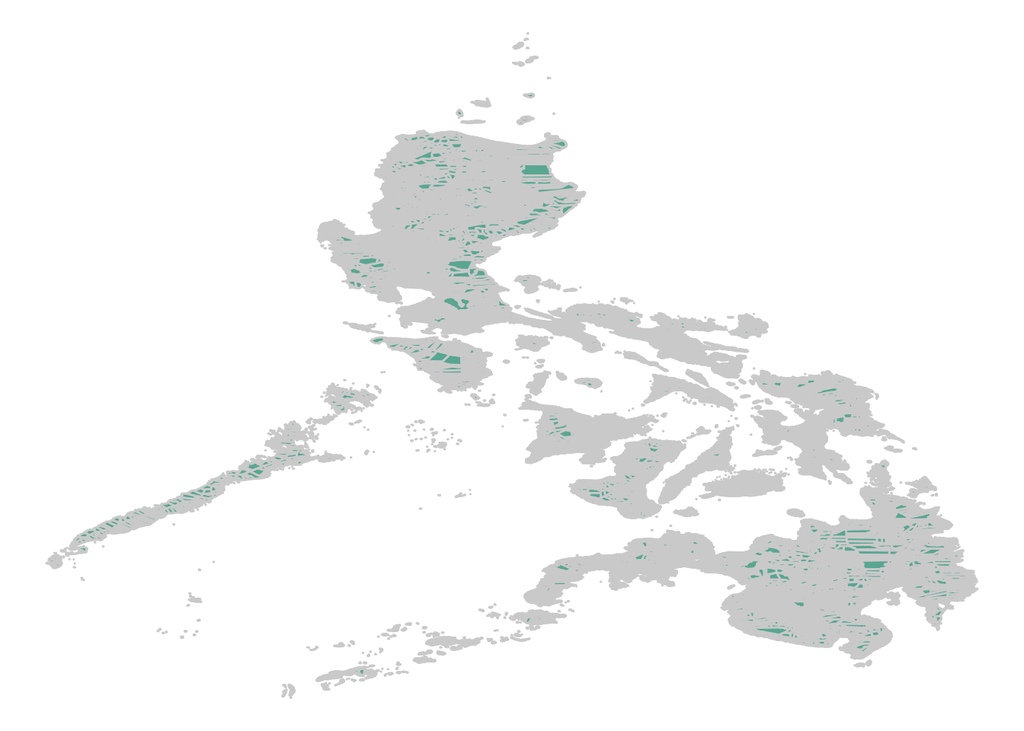

```r
# Plot a basic map which we will add pies to
# We specify the shape_region shapefile should be used for the map, as the majority of data fits this
plot<-
  ggplot() +
  geom_polygon(data = shape_region, aes( x = long, y = lat, group = group), fill="#69b3a2", color="light grey") +
  theme_void()
plot
```

Make maps

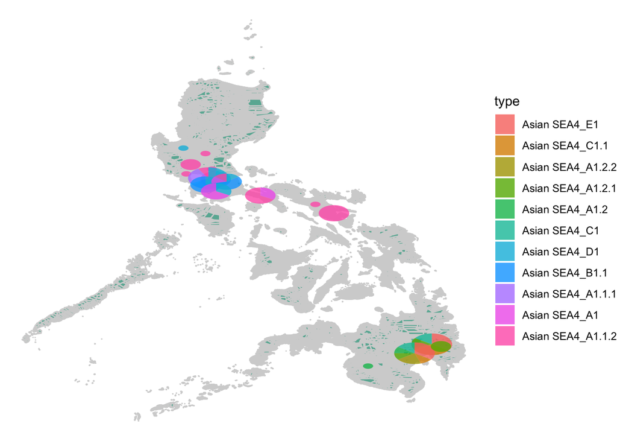

```r
# This adds the pies!
# We are taking the basic map from the last step and telling geom_scatterpie there is data in the lineage_table
# It then uses the LON, LAT, region and radius columns we made in the last step
# We also tell it what the names of the different elements in the pies are (the subclades)
plot_phil<-plot + geom_scatterpie(aes(x=LON, y=LAT, group=region, r=radius/1.5),
                                   data=lineage_table, cols=c(colnames(lineage_table)[2:12]), color=NA, alpha=.8) #need to adjust number of columns map will read based on available lineages

plot_phil
```